# P115-1 Analysis

James Eddy

July 31, 2015

```r
knitr::opts_chunk$set(fig.width=8, fig.height=4, fig.align='center',
                      echo=FALSE, warning=FALSE, message=FALSE)
knitr::opts_knit$set(root.dir = "..")
```

### Set up R environment

#### Load packages

First, load required packages for data munging, visualization, and analysis (these are largely Hadley Wickham libraries, plus some Bioconductor tools).

#### Set working directory

This is a small step that lets me switch between executing chunks interactively and knitting the entire Rmd document without having to constantly modify file paths.

I need to test whether this does anything funky with how knitr saves files for the final HTML document…

#### Define functions

These are functions written by Elizabeth Whalen (shared by Michael Mason) that might come in handy with some steps of the analysis. I might rewrite these at some point to better match my own coding style and/or needs. I’ll also likely move most functions to an external R script, which I can just source here.

#### Load data

Next, load in counts and metrics data for the project, as well as sample annotation for project libraries.

#### Clean data

I need to do a bit of cleaning/formatting with variable names (column headers) to make life easier and avoid breaking downstream functions.

#### Plot metrics

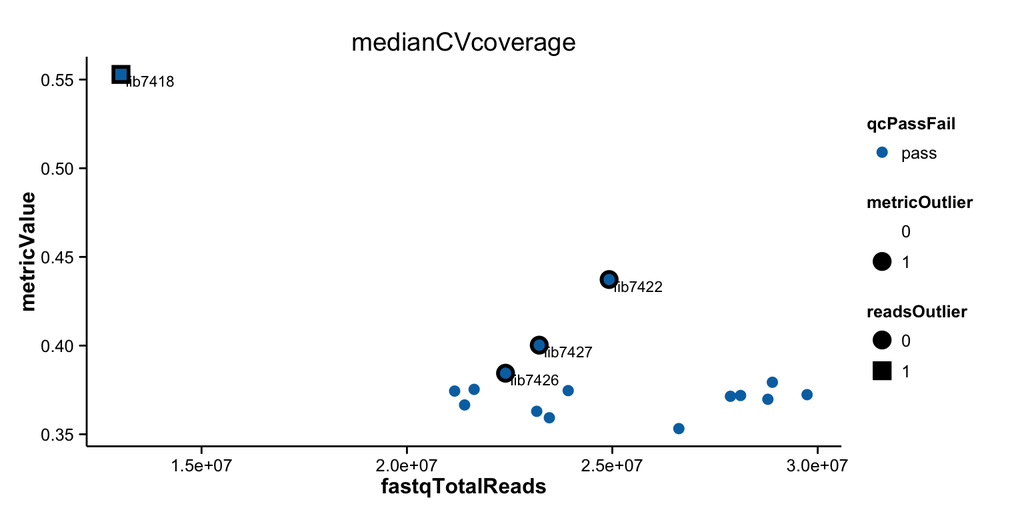

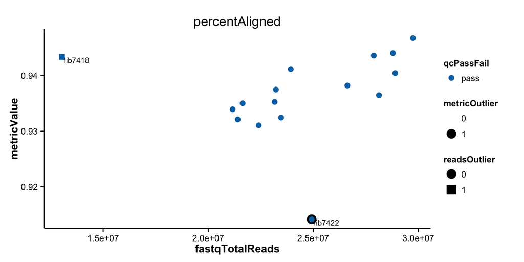

#### Plot data

```
## keepRows
## FALSE  TRUE
## 18210 19781
```

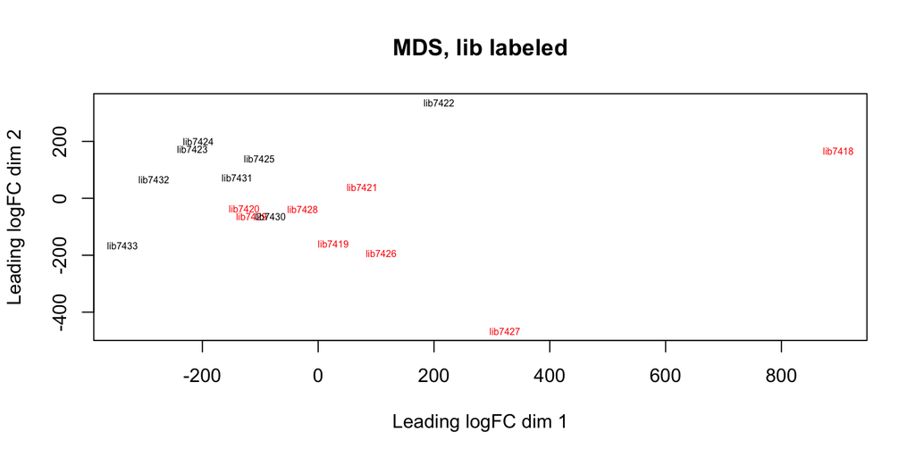